# Analisis Diskriminan Linear dan Kuadratik (LDA & QDA)

Dataset HCV-Egy-Data — Klasifikasi Baselinehistological Staging

Program Studi Statistika — Universitas Sebelas Maret

08 April 2026

# 1 Pendahuluan

## 1.1 Latar Belakang

Hepatitis C Virus (HCV) merupakan penyakit yang menyerang organ hati dan dapat berkembang menjadi fibrosis hingga sirosis apabila tidak ditangani. Tingkat keparahan penyakit ini dinilai melalui **Baselinehistological Staging** (Staging 1–4) yang mencerminkan derajat kerusakan jaringan hati pasien.

Dataset yang digunakan adalah **HCV for Egyptian Patients** dari UCI Machine Learning Repository, yang memuat 28 variabel klinis dan biomarker dari 1.385 pasien. Dengan jumlah variabel yang besar, analisis diskriminan dimanfaatkan tidak hanya sebagai alat klasifikasi, tetapi sekaligus sebagai teknik **reduksi dimensi berbasis kelas** melalui fungsi diskriminan (LD1, LD2, LD3).

## 1.2 Tujuan

1. Membangun model **Linear Discriminant Analysis (LDA)** untuk mengklasifikasikan tingkat staging HCV sekaligus mereduksi dimensi fitur ke ruang LD.
2. Membangun model **Quadratic Discriminant Analysis (QDA)** sebagai pembanding dengan asumsi kovarians berbeda per kelas.
3. Mengevaluasi dan membandingkan performa kedua model.

## 1.3 LDA sebagai Reduksi Dimensi

LDA menghasilkan **fungsi diskriminan** (LD1, LD2, …) yang merupakan kombinasi linear dari prediktor. Berbeda dengan PCA yang memaksimalkan keragaman total (*unsupervised*), LDA memaksimalkan **jarak antar kelas** sambil meminimalkan **keragaman dalam kelas** (*supervised*):

$$D = b_1X_1 + b_2X_2 + \cdots +
b_pX_p$$

Untuk $g$ kelas, LDA menghasilkan maksimal $g-1$ fungsi diskriminan. Dengan 4 kelas Staging, terdapat **3 fungsi diskriminan (LD1, LD2, LD3)** yang memproyeksikan data dari 28 dimensi ke ruang 3 dimensi. Proporsi trace menunjukkan seberapa besar setiap LD menjelaskan pemisahan antar kelas.

# 2 Load Library

```r
library(tidyverse)
library(caret)
library(MASS)       # lda(), qda()
library(klaR)       # partimat()
library(ggplot2)
library(dplyr)
library(reshape2)
library(gridExtra)
```

# 3 Load Dataset

```r
path <- "D:/02. UNS/01. Kuliah/Sem 4/PDM/Diskriminan/HCV-Egy-Data.csv"
df <- read.csv(path, check.names = TRUE)

# Hapus kolom dengan nama kosong (mencegah error zero-length variable name)
df <- df[, nzchar(trimws(colnames(df)))]

## Struktur Data
```

```r
str(df)
```

```
## 'data.frame':    1385 obs. of  29 variables:
##  $ Age                            : int  56 46 57 49 59 58 42 48 44 45 ...
##  $ Gender                         : int  1 1 1 2 1 2 2 2 1 1 ...
##  $ BMI                            : int  35 29 33 33 32 22 26 30 23 30 ...
##  $ Fever                          : int  2 1 2 1 1 2 1 1 1 2 ...
##  $ Nausea.Vomting                 : int  1 2 2 2 1 2 1 1 1 1 ...
##  $ Headache                       : int  1 2 2 1 2 2 2 2 2 2 ...
##  $ Diarrhea                       : int  1 1 2 2 1 1 2 2 2 2 ...
##  $ Fatigue...generalized.bone.ache: int  2 2 1 1 2 2 2 1 2 1 ...
##  $ Jaundice                       : int  2 2 1 2 2 2 2 1 1 1 ...
##  $ Epigastric.pain                : int  2 1 1 1 2 1 2 2 2 2 ...
##  $ WBC                            : int  7425 12101 4178 6490 3661 11785 11620 7335 10480 6681 ...
##  $ RBC                            : num  4248807 4429425 4621191 4794631 4606375 ...
##  $ HGB                            : int  14 10 12 10 11 15 12 11 12 12 ...
##  $ Plat                           : num  112132 129367 151522 146457 187684 ...
##  $ AST.1                          : int  99 91 113 43 99 66 78 119 93 55 ...
##  $ ALT.1                          : int  84 123 49 64 104 104 57 112 83 68 ...
##  $ ALT4                           : num  52 95 95 109 67 121 113 80 55 72 ...
##  $ ALT.12                         : int  109 75 107 80 48 96 118 127 102 127 ...
##  $ ALT.24                         : int  81 113 116 88 120 65 107 45 97 81 ...
##  $ ALT.36                         : int  5 57 5 48 94 73 84 96 122 125 ...
##  $ ALT.48                         : int  5 123 5 77 90 114 80 53 39 43 ...
##  $ ALT.after.24.w                 : int  5 44 5 33 30 29 28 39 45 30 ...
##  $ RNA.Base                       : int  655330 40620 571148 1041941 660410 1157452 325694 641129 591441 1151206 ...
##  $ RNA.4                          : int  634536 538635 661346 449939 738756 1086852 1034008 72050 757361 230488 ...
##  $ RNA.12                         : int  288194 637056 5 585688 3731527 5 275095 787295 5 267320 ...
##  $ RNA.EOT                        : int  5 336804 735945 744463 338946 5 214566 370605 371090 275295 ...
##  $ RNA.EF                         : int  5 31085 558829 582301 242861 5 635157 506296 203042 555516 ...
##  $ Baseline.histological.Grading  : int  13 4 4 10 11 4 12 12 5 4 ...
##  $ Baselinehistological.staging   : int  2 2 4 3 1 4 4 3 2 2 ...
```

## 3.1 Dimensi dan Missing Value

```r
cat("Jumlah baris   :", nrow(df), "\n")
```

```
## Jumlah baris   : 1385
```

```r
cat("Jumlah kolom   :", ncol(df), "\n")
```

```
## Jumlah kolom   : 29
```

```r
cat("Jumlah fitur   :", ncol(df) - 1, "(exclude target)\n")
```

```
## Jumlah fitur   : 28 (exclude target)
```

```r
cat("\n=== CEK MISSING VALUE ===\n")
```

```
##
## === CEK MISSING VALUE ===
```

```r
print(colSums(is.na(df)))
```

```
##                             Age                          Gender
##                               0                               0
##                             BMI                           Fever
##                               0                               0
##                  Nausea.Vomting                        Headache
##                               0                               0
##                        Diarrhea Fatigue...generalized.bone.ache
##                               0                               0
##                        Jaundice                 Epigastric.pain
##                               0                               0
##                             WBC                             RBC
##                               0                               0
##                             HGB                            Plat
##                               0                               0
##                           AST.1                           ALT.1
##                               0                               0
##                            ALT4                          ALT.12
##                               0                               0
##                          ALT.24                          ALT.36
##                               0                               0
##                          ALT.48                  ALT.after.24.w
##                               0                               0
##                        RNA.Base                           RNA.4
##                               0                               0
##                          RNA.12                         RNA.EOT
##                               0                               0
##                          RNA.EF   Baseline.histological.Grading
##                               0                               0
##    Baselinehistological.staging
##                               0
```

```r
cat("\n=== DISTRIBUSI VARIABEL TARGET ===\n")
```

```
##
## === DISTRIBUSI VARIABEL TARGET ===
```

```r
tbl_target <- table(df$Baselinehistological.staging)
print(tbl_target)
```

```
##
##   1   2   3   4
## 336 332 355 362
```

```r
print(prop.table(tbl_target))
```

```
##
##         1         2         3         4
## 0.2425993 0.2397112 0.2563177 0.2613718
```

# 4 Pra-Pemrosesan Data

## 4.1 Rename Kolom

```r
colnames(df)[colnames(df) == "Baselinehistological.staging"]    <- "Staging"
colnames(df)[colnames(df) == "Fatigue...generalized.bone.ache"] <- "Fatigue"
colnames(df)[colnames(df) == "Nausea.Vomting"]                  <- "Nausea"
colnames(df)[colnames(df) == "Epigastric.pain"]                 <- "EpigastricPain"
colnames(df)[colnames(df) == "Baseline.histological.Grading"]   <- "Grading"
colnames(df)[colnames(df) == "ALT.after.24.w"]                  <- "ALT_after24w"
colnames(df)[colnames(df) == "RNA.Base"]                        <- "RNA_Base"
colnames(df)[colnames(df) == "RNA.EOT"]                         <- "RNA_EOT"
colnames(df)[colnames(df) == "RNA.EF"]                          <- "RNA_EF"
colnames(df)[colnames(df) == "AST.1"]                           <- "AST1"
colnames(df)[colnames(df) == "ALT.1"]                           <- "ALT1"
colnames(df)[colnames(df) == "ALT4"]                            <- "ALT4"
colnames(df)[colnames(df) == "ALT.12"]                          <- "ALT12"
colnames(df)[colnames(df) == "ALT.24"]                          <- "ALT24"
colnames(df)[colnames(df) == "ALT.36"]                          <- "ALT36"
colnames(df)[colnames(df) == "ALT.48"]                          <- "ALT48"
colnames(df)[colnames(df) == "RNA.4"]                           <- "RNA4"
colnames(df)[colnames(df) == "RNA.12"]                          <- "RNA12"

df$Staging <- as.factor(df$Staging)
levels(df$Staging) <- c("Staging1", "Staging2", "Staging3", "Staging4")

features <- setdiff(colnames(df), "Staging")
cat("Nama kolom setelah cleaning:\n")
```

```
## Nama kolom setelah cleaning:
```

```r
print(colnames(df))
```

```
##  [1] "Age"            "Gender"         "BMI"            "Fever"
##  [5] "Nausea"         "Headache"       "Diarrhea"       "Fatigue"
##  [9] "Jaundice"       "EpigastricPain" "WBC"            "RBC"
## [13] "HGB"            "Plat"           "AST1"           "ALT1"
## [17] "ALT4"           "ALT12"          "ALT24"          "ALT36"
## [21] "ALT48"          "ALT_after24w"   "RNA_Base"       "RNA4"
## [25] "RNA12"          "RNA_EOT"        "RNA_EF"         "Grading"
## [29] "Staging"
```

```r
cat("\nTotal fitur prediktor:", length(features), "\n")
```

```
##
## Total fitur prediktor: 28
```

## 4.2 Cek Duplikasi

Pengecekan baris duplikat dilakukan untuk memastikan tidak ada observasi yang tercatat lebih dari satu kali. Baris duplikat dapat menyebabkan model *overfit* karena data yang sama muncul di training dan testing set.

```r
n_duplikat <- sum(duplicated(df))
cat("Jumlah baris duplikat :", n_duplikat, "\n")
```

```
## Jumlah baris duplikat : 0
```

```r
if (n_duplikat > 0) {
  cat("\nIndeks baris duplikat:\n")
  print(which(duplicated(df)))

  cat("\nContoh baris duplikat (5 pertama):\n")
  print(head(df[duplicated(df), ], 5))

  # Hapus duplikat
  df <- df[!duplicated(df), ]
  cat("\nDuplikat dihapus. Sisa baris:", nrow(df), "\n")
} else {
  cat("Tidak ditemukan duplikat. Data bersih.\n")
}
```

```
## Tidak ditemukan duplikat. Data bersih.
```

## 4.3 Cek Outlier dengan Interquartile Range (IQR)

Metode IQR mendefinisikan outlier sebagai nilai di luar batas:

$$\text{Batas Bawah} = Q1 - 1.5 \times IQR
\quad ; \quad \text{Batas Atas} = Q3 + 1.5 \times IQR$$

Pengecekan dilakukan pada **seluruh variabel numerik** (fitur prediktor). Variabel kategoris biner (nilai hanya 1 dan 2) dilewati karena metode IQR tidak relevan untuk variabel tersebut.

```r
# Identifikasi variabel numerik kontinu (lebih dari 2 nilai unik)
vars_numerik <- features[sapply(df[, features], function(x) {
  is.numeric(x) && length(unique(x)) > 2
})]

cat("Variabel yang dicek outlier:", length(vars_numerik), "variabel\n")
```

```
## Variabel yang dicek outlier: 20 variabel
```

```r
cat(paste(vars_numerik, collapse = ", "), "\n\n")
```

```
## Age, BMI, WBC, RBC, HGB, Plat, AST1, ALT1, ALT4, ALT12, ALT24, ALT36, ALT48, ALT_after24w, RNA_Base, RNA4, RNA12, RNA_EOT, RNA_EF, Grading
```

```r
# Hitung jumlah outlier per variabel
outlier_summary <- data.frame(
  Variabel     = vars_numerik,
  Q1           = NA_real_,
  Q3           = NA_real_,
  IQR          = NA_real_,
  Batas_Bawah  = NA_real_,
  Batas_Atas   = NA_real_,
  N_Outlier    = NA_integer_,
  Pct_Outlier  = NA_real_
)

for (i in seq_along(vars_numerik)) {
  v   <- vars_numerik[i]
  x   <- df[[v]]
  q1  <- quantile(x, 0.25, na.rm = TRUE)
  q3  <- quantile(x, 0.75, na.rm = TRUE)
  iqr <- q3 - q1
  lb  <- q1 - 1.5 * iqr
  ub  <- q3 + 1.5 * iqr
  n_out <- sum(x < lb | x > ub, na.rm = TRUE)

  outlier_summary[i, "Q1"]          <- round(q1,  2)
  outlier_summary[i, "Q3"]          <- round(q3,  2)
  outlier_summary[i, "IQR"]         <- round(iqr, 2)
  outlier_summary[i, "Batas_Bawah"] <- round(lb,  2)
  outlier_summary[i, "Batas_Atas"]  <- round(ub,  2)
  outlier_summary[i, "N_Outlier"]   <- n_out
  outlier_summary[i, "Pct_Outlier"] <- round(n_out / nrow(df) * 100, 2)
}

cat("=== RINGKASAN OUTLIER PER VARIABEL ===\n")
```

```
## === RINGKASAN OUTLIER PER VARIABEL ===
```

```r
print(outlier_summary)
```

```
##        Variabel      Q1      Q3    IQR Batas_Bawah Batas_Atas N_Outlier
## 1           Age      39      54     15        16.5       76.5         0
## 2           BMI      25      32      7        14.5       42.5         0
## 3           WBC    5219    9902   4683     -1805.5    16926.5         0
## 4           RBC 4121374 4721279 599905   3221516.5  5621136.5         0
## 5           HGB      11      14      3         6.5       18.5         0
## 6          Plat  124479  190314  65835     25726.5   289066.5         0
## 7          AST1      60     105     45        -7.5      172.5         0
## 8          ALT1      62     106     44        -4.0      172.0         0
## 9          ALT4      61     107     46        -8.0      176.0         0
## 10        ALT12      60     106     46        -9.0      175.0         0
## 11        ALT24      61     107     46        -8.0      176.0         0
## 12        ALT36      61     106     45        -6.5      173.5         0
## 13        ALT48      61     106     45        -6.5      173.5         0
## 14 ALT_after24w      28      40     12        10.0       58.0         3
```

[output cut: 27 more lines]

```r
cat("\nTotal variabel yang memiliki outlier:",
    sum(outlier_summary$N_Outlier > 0), "\n")
```

```
##
## Total variabel yang memiliki outlier: 2
```

```r
cat("Total sel outlier (seluruh variabel):",
    sum(outlier_summary$N_Outlier), "\n")
```

```
## Total sel outlier (seluruh variabel): 4
```

### 4.3.1 Visualisasi Outlier — Boxplot Per Variabel

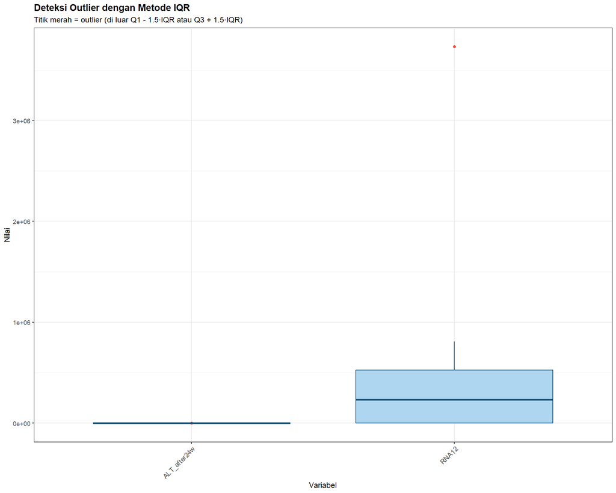

```r
# Ambil hanya variabel yang memiliki outlier untuk divisualisasikan
vars_ada_outlier <- outlier_summary$Variabel[outlier_summary$N_Outlier > 0]

if (length(vars_ada_outlier) > 0) {
  df_long <- df[, vars_ada_outlier] %>%
    pivot_longer(cols = everything(),
                 names_to  = "Variabel",
                 values_to = "Nilai")

  ggplot(df_long, aes(x = Variabel, y = Nilai)) +
    geom_boxplot(fill = "#aed6f1", color = "#1a5276",
                 outlier.color = "#e74c3c",
                 outlier.shape = 16,
                 outlier.size  = 1.2,
                 linewidth = 0.5) +
    labs(
      title    = "Deteksi Outlier dengan Metode IQR",
      subtitle = "Titik merah = outlier (di luar Q1 - 1.5·IQR atau Q3 + 1.5·IQR)",
      x        = "Variabel",
      y        = "Nilai"
    ) +
    theme_bw(base_size = 9) +
    theme(
      plot.title   = element_text(face = "bold"),
      axis.text.x  = element_text(angle = 45, hjust = 1, size = 8)
    )
} else {
  cat("Tidak ada variabel dengan outlier yang perlu divisualisasikan.\n")
}
```

### 4.3.2 Ringkasan Outlier — Bar Chart Persentase

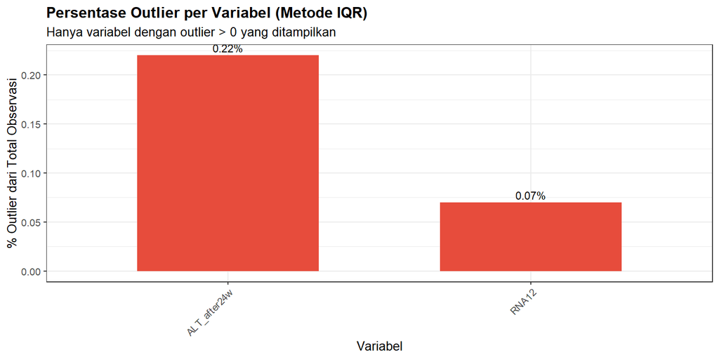

```r
outlier_plot_df <- outlier_summary %>%
  filter(N_Outlier > 0) %>%
  arrange(desc(Pct_Outlier)) %>%
  mutate(Variabel = factor(Variabel, levels = Variabel))

if (nrow(outlier_plot_df) > 0) {
  ggplot(outlier_plot_df,
         aes(x = Variabel, y = Pct_Outlier)) +
    geom_bar(stat = "identity", fill = "#e74c3c", width = 0.6) +
    geom_text(aes(label = paste0(Pct_Outlier, "%")),
              vjust = -0.4, size = 3) +
    labs(
      title    = "Persentase Outlier per Variabel (Metode IQR)",
      subtitle = "Hanya variabel dengan outlier > 0 yang ditampilkan",
      x        = "Variabel",
      y        = "% Outlier dari Total Observasi"
    ) +
    theme_bw(base_size = 10) +
    theme(
      plot.title  = element_text(face = "bold"),
      axis.text.x = element_text(angle = 45, hjust = 1, size = 8)
    )
} else {
  cat("Tidak ada outlier yang ditemukan.\n")
}
```

### 4.3.3 Penanganan Outlier

Untuk analisis diskriminan, outlier **tidak dihapus** melainkan **di-*cap*** (*winsorizing*) pada batas IQR. Strategi ini mempertahankan jumlah observasi (penting untuk estimasi kovarians pada QDA) sambil mengurangi pengaruh nilai ekstrem terhadap fungsi diskriminan.

$$x_{\text{cap}} = \begin{cases}
\text{Batas Bawah} & \text{jika } x < Q1 - 1.5 \times IQR \\
x & \text{jika } Q1 - 1.5 \times IQR \leq x \leq Q3 + 1.5 \times IQR
\\
\text{Batas Atas} & \text{jika } x > Q3 + 1.5 \times IQR
\end{cases}$$

```r
df_clean <- df

for (v in vars_numerik) {
  x   <- df_clean[[v]]
  q1  <- quantile(x, 0.25, na.rm = TRUE)
  q3  <- quantile(x, 0.75, na.rm = TRUE)
  iqr <- q3 - q1
  lb  <- q1 - 1.5 * iqr
  ub  <- q3 + 1.5 * iqr
  df_clean[[v]] <- pmin(pmax(x, lb), ub)
}

# Verifikasi: hitung outlier setelah winsorizing
n_outlier_after <- sum(sapply(vars_numerik, function(v) {
  x   <- df_clean[[v]]
  q1  <- quantile(x, 0.25, na.rm = TRUE)
  q3  <- quantile(x, 0.75, na.rm = TRUE)
  iqr <- q3 - q1
  sum(x < q1 - 1.5 * iqr | x > q3 + 1.5 * iqr, na.rm = TRUE)
}))

cat("Jumlah outlier SEBELUM winsorizing:", sum(outlier_summary$N_Outlier), "\n")
```

```
## Jumlah outlier SEBELUM winsorizing: 4
```

```r
cat("Jumlah outlier SETELAH winsorizing:", n_outlier_after, "\n")
```

```
## Jumlah outlier SETELAH winsorizing: 0
```

```r
cat("Dimensi data setelah penanganan   :", nrow(df_clean), "x", ncol(df_clean), "\n")
```

```
## Dimensi data setelah penanganan   : 1385 x 29
```

## 4.4 Standardisasi Fitur (Z-Score)

Standardisasi dilakukan pada data bersih (`df_clean`) — setelah penanganan duplikat dan outlier — agar setiap variabel berada pada skala yang sebanding.

```r
df_scaled <- df_clean
df_scaled[, features] <- as.data.frame(scale(df_clean[, features]))
```

# 5 Split Data Train & Test (70:30 Stratified)

```r
set.seed(123)
train_idx  <- createDataPartition(df_scaled$Staging, p = 0.7, list = FALSE)
data_train <- df_scaled[ train_idx, ]
data_test  <- df_scaled[-train_idx, ]

cat("Data latih :", nrow(data_train), "observasi\n")
```

```
## Data latih : 972 observasi
```

```r
cat("Data uji   :", nrow(data_test),  "observasi\n")
```

```
## Data uji   : 413 observasi
```

```r
cat("\nDistribusi kelas — Data Latih:\n")
```

```
##
## Distribusi kelas — Data Latih:
```

```r
print(table(data_train$Staging))
```

```
##
## Staging1 Staging2 Staging3 Staging4
##      236      233      249      254
```

```r
cat("\nDistribusi kelas — Data Uji:\n")
```

```
##
## Distribusi kelas — Data Uji:
```

```r
print(table(data_test$Staging))
```

```
##
## Staging1 Staging2 Staging3 Staging4
##      100       99      106      108
```

# 6 Linear Discriminant Analysis (LDA)

## 6.1 Melatih Model LDA

```r
model_lda <- lda(Staging ~ ., data = data_train)
print(model_lda)
```

```
## Call:
## lda(Staging ~ ., data = data_train)
##
## Prior probabilities of groups:
##  Staging1  Staging2  Staging3  Staging4
## 0.2427984 0.2397119 0.2561728 0.2613169
##
## Group means:
##                  Age      Gender          BMI       Fever      Nausea
## Staging1 -0.04116680  0.01246228 -0.006907335  0.07913214 -0.03893889
## Staging2  0.07509045 -0.09492773  0.192871439  0.03333479 -0.04366555
## Staging3  0.03271559  0.10526104 -0.008431122  0.03723067  0.01502094
## Staging4 -0.08745112  0.02880856 -0.147389230 -0.07042553  0.02643270
##             Headache    Diarrhea     Fatigue    Jaundice EpigastricPain
## Staging1  0.04182675  0.06272060 -0.05713547 -0.01063682     0.08525000
## Staging2 -0.03067426 -0.02650414 -0.01928624  0.03644746    -0.08087695
## Staging3 -0.04425201  0.05516759 -0.04199557 -0.08647238    -0.09224918
## Staging4  0.01581104  0.05004652  0.05726363  0.06867543     0.03928890
##                  WBC          RBC         HGB         Plat         AST1
## Staging1 -0.01277460 -0.004632153  0.05513693 -0.047917098  0.011600782
## Staging2 -0.04539041 -0.023528199  0.03772072  0.099416138  0.002887526
## Staging3 -0.03541789 -0.017863048 -0.03127443 -0.008423181  0.003413371
## Staging4  0.04323104 -0.016507172  0.04070862 -0.042663762 -0.097660336
##                 ALT1         ALT4        ALT12        ALT24        ALT36
## Staging1 -0.08503638  0.015051362  0.001874303  0.048777499  0.003246343
## Staging2  0.03336331  0.002985419 -0.064867090 -0.005929071 -0.035835244
## Staging3  0.01051235  0.065238886 -0.076132923 -0.018320603 -0.021496574
## Staging4  0.06762564 -0.083855879  0.061226237  0.012004764  0.030290252
##                 ALT48 ALT_after24w    RNA_Base        RNA4       RNA12
## Staging1 -0.040328356  -0.04155957  0.07645703  0.07828545  0.02216276
## Staging2  0.017070283  -0.06140861 -0.11574169  0.05099877 -0.07175850
## Staging3  0.049653991   0.02579360  0.04280821  0.01317952  0.01181295
## Staging4 -0.009746323   0.04753783  0.03611084 -0.04085885  0.11859502
##              RNA_EOT       RNA_EF     Grading
## Staging1  0.14305299 -0.006916713  0.04341757
## Staging2 -0.10623974 -0.101179568  0.04854715
## Staging3 -0.02516523  0.086308247 -0.01564098
## Staging4 -0.01384450 -0.004377552 -0.02982198
##
## Coefficients of linear discriminants:
```

[output cut: 18 more lines]

```
## ALT12          -0.235032261  0.000646653  0.18647315
## ALT24          -0.068976459 -0.121357218  0.10947546
## ALT36          -0.113472361  0.001774546  0.04624063
## ALT48           0.055847118  0.084377488 -0.16011193
## ALT_after24w   -0.158298318  0.134311922 -0.15451587
## RNA_Base       -0.223969439 -0.271529834 -0.17268027
## RNA4            0.127926783 -0.194573409  0.04312482
## RNA12          -0.385260107  0.255811118  0.11433871
## RNA_EOT        -0.002753399 -0.689494586  0.24105531
## RNA_EF          0.137564016  0.091599413 -0.61316789
## Grading         0.138220305 -0.169724522  0.11274798
##
## Proportion of trace:
##    LD1    LD2    LD3
## 0.5094 0.2582 0.2324
```

## 6.2 LDA sebagai Reduksi Dimensi: Proporsi Trace

Proporsi trace menunjukkan seberapa besar setiap fungsi diskriminan berkontribusi dalam memisahkan antar kelas. LDA mereduksi dimensi fitur menjadi maksimal **3 dimensi** (LD1, LD2, LD3) untuk 4 kelas.

```r
ev     <- model_lda$svd^2 / sum(model_lda$svd^2)
ev_pct <- round(ev * 100, 2)

ev_tbl <- data.frame(
  Fungsi     = paste0("LD", 1:3),
  Proporsi   = paste0(ev_pct, "%"),
  Kumulatif  = paste0(round(cumsum(ev_pct), 2), "%")
)
print(ev_tbl)
```

```
##   Fungsi Proporsi Kumulatif
## 1    LD1   50.94%    50.94%
## 2    LD2   25.82%    76.76%
## 3    LD3   23.24%      100%
```

```r
cat(sprintf("\nLD1 menjelaskan %.2f%% pemisahan antar kelas.\n", ev_pct[1]))
```

```
##
## LD1 menjelaskan 50.94% pemisahan antar kelas.
```

```r
cat(sprintf("LD1 + LD2 menjelaskan %.2f%% pemisahan antar kelas.\n",
            sum(ev_pct[1:2])))
```

```
## LD1 + LD2 menjelaskan 76.76% pemisahan antar kelas.
```

## 6.3 Koefisien Fungsi Diskriminan

Koefisien ini membentuk **persamaan fungsi diskriminan** yang memproyeksikan data ke ruang berdimensi lebih rendah. Variabel dengan nilai absolut koefisien terbesar paling berpengaruh dalam pemisahan kelas.

```r
round(model_lda$scaling, 4)
```

```
##                    LD1     LD2     LD3
## Age             0.2981  0.0435 -0.0907
## Gender         -0.2039 -0.0897 -0.4332
## BMI             0.5846 -0.0066  0.1712
## Fever           0.2102 -0.2789 -0.0653
## Nausea         -0.1133  0.0749 -0.1488
## Headache       -0.0829 -0.1179  0.1504
## Diarrhea       -0.1404 -0.1264 -0.0400
## Fatigue        -0.1088  0.1741  0.0816
## Jaundice       -0.0180  0.1666  0.3911
## EpigastricPain -0.2150 -0.2451  0.2962
## WBC            -0.1876  0.0822  0.0427
## RBC            -0.0435 -0.0628  0.0057
## HGB            -0.0955 -0.0451  0.2280
## Plat            0.2372  0.1378  0.0932
## AST1            0.1606 -0.2255 -0.0864
## ALT1           -0.0692  0.3756  0.0329
## ALT4            0.1759 -0.1273 -0.2472
## ALT12          -0.2350  0.0006  0.1865
## ALT24          -0.0690 -0.1214  0.1095
## ALT36          -0.1135  0.0018  0.0462
## ALT48           0.0558  0.0844 -0.1601
## ALT_after24w   -0.1583  0.1343 -0.1545
## RNA_Base       -0.2240 -0.2715 -0.1727
## RNA4            0.1279 -0.1946  0.0431
## RNA12          -0.3853  0.2558  0.1143
## RNA_EOT        -0.0028 -0.6895  0.2411
## RNA_EF          0.1376  0.0916 -0.6132
## Grading         0.1382 -0.1697  0.1127
```

## 6.4 Peluang Posterior (6 Data Pertama — Data Latih)

```r
pred_train_lda <- predict(model_lda, data_train)
round(head(pred_train_lda$posterior), 4)
```

```
##    Staging1 Staging2 Staging3 Staging4
## 5    0.2016   0.3291   0.1481   0.3212
## 6    0.1892   0.1680   0.2961   0.3468
## 7    0.2798   0.1656   0.2273   0.3273
## 8    0.2197   0.1646   0.2629   0.3528
## 9    0.2846   0.1156   0.1584   0.4413
## 10   0.3421   0.1343   0.2248   0.2989
```

## 6.5 Evaluasi Model LDA

### 6.5.1 Confusion Matrix — Data Latih

```r
cm_train_lda <- confusionMatrix(pred_train_lda$class, data_train$Staging)
print(cm_train_lda$table)
```

```
##           Reference
## Prediction Staging1 Staging2 Staging3 Staging4
##   Staging1       62       39       43       35
##   Staging2       46       82       54       48
##   Staging3       48       57       80       54
##   Staging4       80       55       72      117
```

```r
cat(sprintf("\nAkurasi LDA (train): %.2f%%\n",
            cm_train_lda$overall["Accuracy"] * 100))
```

```
##
## Akurasi LDA (train): 35.08%
```

### 6.5.2 Confusion Matrix — Data Uji

```r
pred_test_lda <- predict(model_lda, data_test)
cm_test_lda   <- confusionMatrix(pred_test_lda$class, data_test$Staging)
print(cm_test_lda$table)
```

```
##           Reference
## Prediction Staging1 Staging2 Staging3 Staging4
##   Staging1       14       23       21       12
##   Staging2       29       23       20       31
##   Staging3       27       19       32       26
##   Staging4       30       34       33       39
```

```r
cat(sprintf("\nAkurasi LDA (test): %.2f%%\n",
            cm_test_lda$overall["Accuracy"] * 100))
```

```
##
## Akurasi LDA (test): 26.15%
```

### 6.5.3 Statistik Per Kelas — Data Uji

```r
cm_test_lda$byClass[, c("Sensitivity", "Specificity", "Precision", "F1")]
```

```
##                 Sensitivity Specificity Precision        F1
## Class: Staging1   0.1400000   0.8210863 0.2000000 0.1647059
## Class: Staging2   0.2323232   0.7452229 0.2233010 0.2277228
## Class: Staging3   0.3018868   0.7654723 0.3076923 0.3047619
## Class: Staging4   0.3611111   0.6819672 0.2867647 0.3196721
```

# 7 Quadratic Discriminant Analysis (QDA)

## 7.1 Melatih Model QDA

```r
model_qda <- qda(Staging ~ ., data = data_train)
print(model_qda)
```

```
## Call:
## qda(Staging ~ ., data = data_train)
##
## Prior probabilities of groups:
##  Staging1  Staging2  Staging3  Staging4
## 0.2427984 0.2397119 0.2561728 0.2613169
##
## Group means:
##                  Age      Gender          BMI       Fever      Nausea
## Staging1 -0.04116680  0.01246228 -0.006907335  0.07913214 -0.03893889
## Staging2  0.07509045 -0.09492773  0.192871439  0.03333479 -0.04366555
## Staging3  0.03271559  0.10526104 -0.008431122  0.03723067  0.01502094
## Staging4 -0.08745112  0.02880856 -0.147389230 -0.07042553  0.02643270
##             Headache    Diarrhea     Fatigue    Jaundice EpigastricPain
## Staging1  0.04182675  0.06272060 -0.05713547 -0.01063682     0.08525000
## Staging2 -0.03067426 -0.02650414 -0.01928624  0.03644746    -0.08087695
## Staging3 -0.04425201  0.05516759 -0.04199557 -0.08647238    -0.09224918
## Staging4  0.01581104  0.05004652  0.05726363  0.06867543     0.03928890
##                  WBC          RBC         HGB         Plat         AST1
## Staging1 -0.01277460 -0.004632153  0.05513693 -0.047917098  0.011600782
## Staging2 -0.04539041 -0.023528199  0.03772072  0.099416138  0.002887526
## Staging3 -0.03541789 -0.017863048 -0.03127443 -0.008423181  0.003413371
## Staging4  0.04323104 -0.016507172  0.04070862 -0.042663762 -0.097660336
##                 ALT1         ALT4        ALT12        ALT24        ALT36
## Staging1 -0.08503638  0.015051362  0.001874303  0.048777499  0.003246343
## Staging2  0.03336331  0.002985419 -0.064867090 -0.005929071 -0.035835244
## Staging3  0.01051235  0.065238886 -0.076132923 -0.018320603 -0.021496574
## Staging4  0.06762564 -0.083855879  0.061226237  0.012004764  0.030290252
##                 ALT48 ALT_after24w    RNA_Base        RNA4       RNA12
## Staging1 -0.040328356  -0.04155957  0.07645703  0.07828545  0.02216276
## Staging2  0.017070283  -0.06140861 -0.11574169  0.05099877 -0.07175850
## Staging3  0.049653991   0.02579360  0.04280821  0.01317952  0.01181295
## Staging4 -0.009746323   0.04753783  0.03611084 -0.04085885  0.11859502
##              RNA_EOT       RNA_EF     Grading
## Staging1  0.14305299 -0.006916713  0.04341757
## Staging2 -0.10623974 -0.101179568  0.04854715
## Staging3 -0.02516523  0.086308247 -0.01564098
## Staging4 -0.01384450 -0.004377552 -0.02982198
```

## 7.2 Evaluasi Model QDA

### 7.2.1 Confusion Matrix — Data Latih

```r
pred_train_qda <- predict(model_qda, data_train)
cm_train_qda   <- confusionMatrix(pred_train_qda$class, data_train$Staging)
print(cm_train_qda$table)
```

```
##           Reference
## Prediction Staging1 Staging2 Staging3 Staging4
##   Staging1      129       24       30       23
##   Staging2       38      156       27       26
##   Staging3       39       28      160       31
##   Staging4       30       25       32      174
```

```r
cat(sprintf("\nAkurasi QDA (train): %.2f%%\n",
            cm_train_qda$overall["Accuracy"] * 100))
```

```
##
## Akurasi QDA (train): 63.68%
```

### 7.2.2 Confusion Matrix — Data Uji

```r
pred_test_qda <- predict(model_qda, data_test)
cm_test_qda   <- confusionMatrix(pred_test_qda$class, data_test$Staging)
print(cm_test_qda$table)
```

```
##           Reference
## Prediction Staging1 Staging2 Staging3 Staging4
##   Staging1       20       29       31       19
##   Staging2       23       25       18       22
##   Staging3       29       28       31       29
##   Staging4       28       17       26       38
```

```r
cat(sprintf("\nAkurasi QDA (test): %.2f%%\n",
            cm_test_qda$overall["Accuracy"] * 100))
```

```
##
## Akurasi QDA (test): 27.60%
```

### 7.2.3 Statistik Per Kelas — Data Uji

```r
cm_test_qda$byClass[, c("Sensitivity", "Specificity", "Precision", "F1")]
```

```
##                 Sensitivity Specificity Precision        F1
## Class: Staging1   0.2000000   0.7476038 0.2020202 0.2010050
## Class: Staging2   0.2525253   0.7993631 0.2840909 0.2673797
## Class: Staging3   0.2924528   0.7198697 0.2649573 0.2780269
## Class: Staging4   0.3518519   0.7672131 0.3486239 0.3502304
```

# 8 Ringkasan Perbandingan Model

```r
summary_tbl <- data.frame(
  Model         = c("LDA", "QDA"),
  Akurasi_Train = c(round(cm_train_lda$overall["Accuracy"] * 100, 2),
                    round(cm_train_qda$overall["Accuracy"] * 100, 2)),
  Akurasi_Test  = c(round(cm_test_lda$overall["Accuracy"] * 100, 2),
                    round(cm_test_qda$overall["Accuracy"] * 100, 2))
)
summary_tbl$Gap_Overfit <- summary_tbl$Akurasi_Train - summary_tbl$Akurasi_Test
print(summary_tbl)
```

```
##   Model Akurasi_Train Akurasi_Test Gap_Overfit
## 1   LDA         35.08        26.15        8.93
## 2   QDA         63.68        27.60       36.08
```

# 9 Visualisasi

## 9.1 7.1 Proyeksi LDA (LD1 vs LD2) — Hasil Reduksi Dimensi

Plot ini menampilkan data yang telah direduksi dari dimensi fitur ke ruang LD1 dan LD2. Semakin terpisah klaster antar warna, semakin baik kemampuan LDA memisahkan kelas.

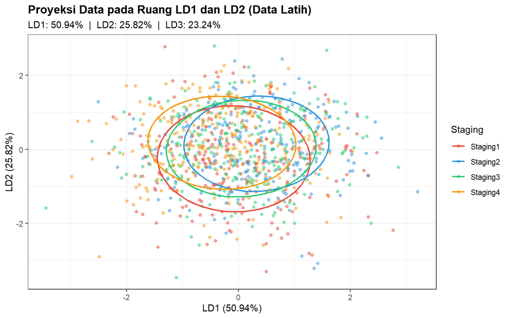

```r
lda_scores <- as.data.frame(pred_train_lda$x)
lda_scores$Staging <- data_train$Staging

ggplot(lda_scores, aes(x = LD1, y = LD2, color = Staging)) +
  geom_point(alpha = 0.5, size = 1.5) +
  stat_ellipse(level = 0.68, linewidth = 0.8) +
  labs(
    title    = "Proyeksi Data pada Ruang LD1 dan LD2 (Data Latih)",
    subtitle = sprintf("LD1: %.2f%%  |  LD2: %.2f%%  |  LD3: %.2f%%",
                       ev_pct[1], ev_pct[2], ev_pct[3]),
    x     = sprintf("LD1 (%.2f%%)", ev_pct[1]),
    y     = sprintf("LD2 (%.2f%%)", ev_pct[2]),
    color = "Staging"
  ) +
  scale_color_manual(values = c("#e74c3c", "#3498db", "#2ecc71", "#f39c12")) +
  theme_bw(base_size = 11) +
  theme(plot.title = element_text(face = "bold"))
```

## 9.2 7.2 Proporsi Trace (Explained Variance Antar Kelas)

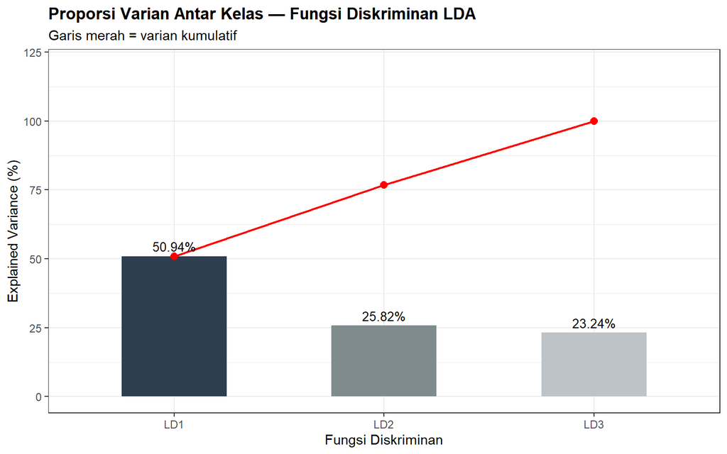

```r
ev_df <- data.frame(
  LD  = paste0("LD", 1:3),
  Var = ev_pct,
  Cum = cumsum(ev_pct)
)

ggplot(ev_df, aes(x = LD, y = Var)) +
  geom_bar(stat = "identity",
           fill = c("#2c3e50", "#7f8c8d", "#bdc3c7"), width = 0.5) +
  geom_line(aes(y = Cum, group = 1), color = "red", linewidth = 0.8) +
  geom_point(aes(y = Cum), color = "red", size = 2.5) +
  geom_text(aes(label = paste0(Var, "%")), vjust = -0.5, size = 3.5) +
  ylim(0, 120) +
  labs(
    title    = "Proporsi Varian Antar Kelas — Fungsi Diskriminan LDA",
    subtitle = "Garis merah = varian kumulatif",
    x        = "Fungsi Diskriminan",
    y        = "Explained Variance (%)"
  ) +
  theme_bw(base_size = 11) +
  theme(plot.title = element_text(face = "bold"))
```

## 9.3 7.3 Koefisien LD1 — Kontribusi Variabel Asli

Koefisien LD1 menunjukkan seberapa besar setiap variabel asli berkontribusi pada fungsi diskriminan pertama. Ini merupakan interpretasi reduksi dimensi LDA: variabel mana yang paling membedakan antar kelas Staging.

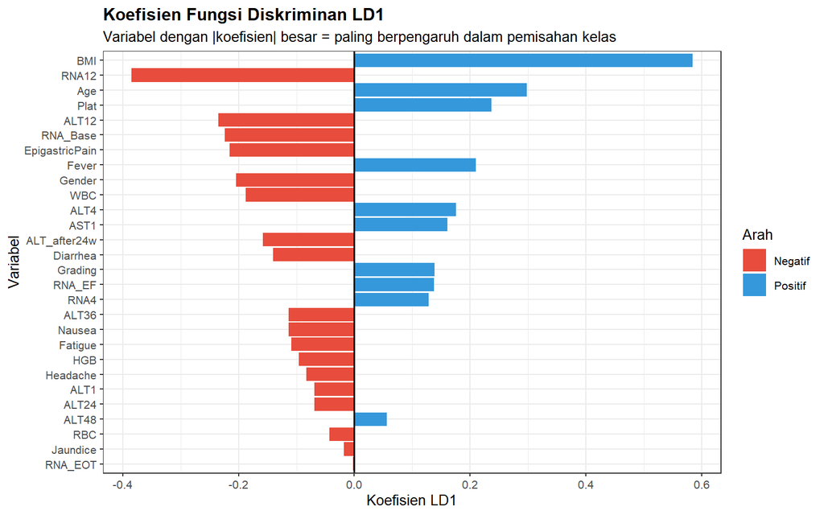

```r
scaling_df <- as.data.frame(model_lda$scaling)
scaling_df$Variabel <- rownames(scaling_df)
scaling_df <- scaling_df %>%
  arrange(abs(LD1)) %>%
  mutate(
    Variabel = factor(Variabel, levels = Variabel),
    Warna    = ifelse(LD1 >= 0, "Positif", "Negatif")
  )

ggplot(scaling_df, aes(x = LD1, y = Variabel, fill = Warna)) +
  geom_bar(stat = "identity") +
  geom_vline(xintercept = 0, linewidth = 0.6) +
  scale_fill_manual(values = c("Positif" = "#3498db", "Negatif" = "#e74c3c")) +
  labs(
    title    = "Koefisien Fungsi Diskriminan LD1",
    subtitle = "Variabel dengan |koefisien| besar = paling berpengaruh dalam pemisahan kelas",
    x    = "Koefisien LD1",
    y    = "Variabel",
    fill = "Arah"
  ) +
  theme_bw(base_size = 10) +
  theme(
    plot.title  = element_text(face = "bold"),
    axis.text.y = element_text(size = 8)
  )
```

## 9.4 7.4 Koefisien LD2 — Kontribusi Variabel Asli

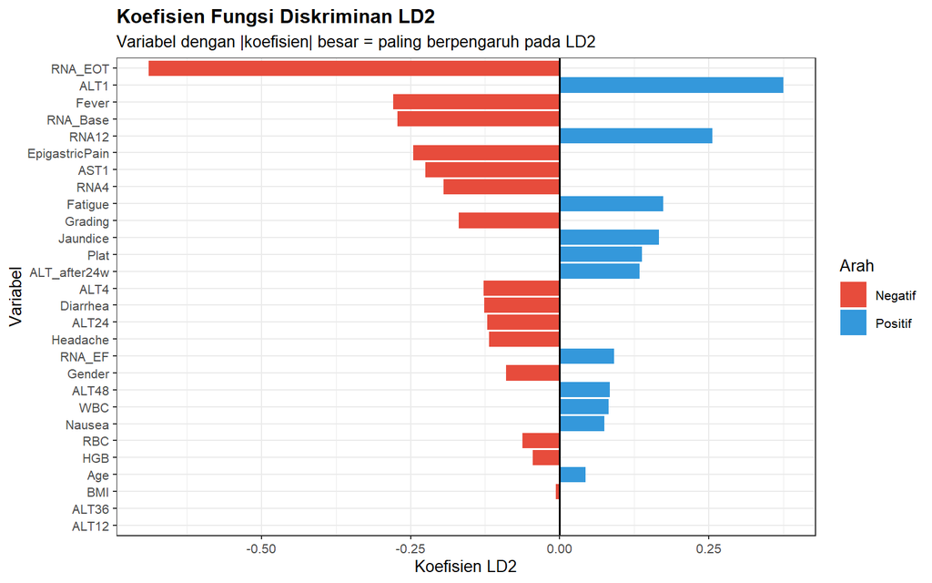

```r
scaling_df2 <- as.data.frame(model_lda$scaling)
scaling_df2$Variabel <- rownames(scaling_df2)
scaling_df2 <- scaling_df2 %>%
  arrange(abs(LD2)) %>%
  mutate(
    Variabel = factor(Variabel, levels = Variabel),
    Warna    = ifelse(LD2 >= 0, "Positif", "Negatif")
  )

ggplot(scaling_df2, aes(x = LD2, y = Variabel, fill = Warna)) +
  geom_bar(stat = "identity") +
  geom_vline(xintercept = 0, linewidth = 0.6) +
  scale_fill_manual(values = c("Positif" = "#3498db", "Negatif" = "#e74c3c")) +
  labs(
    title    = "Koefisien Fungsi Diskriminan LD2",
    subtitle = "Variabel dengan |koefisien| besar = paling berpengaruh pada LD2",
    x    = "Koefisien LD2",
    y    = "Variabel",
    fill = "Arah"
  ) +
  theme_bw(base_size = 10) +
  theme(
    plot.title  = element_text(face = "bold"),
    axis.text.y = element_text(size = 8)
  )
```

## 9.5 7.5 Confusion Matrix Heatmap — LDA (Data Uji)

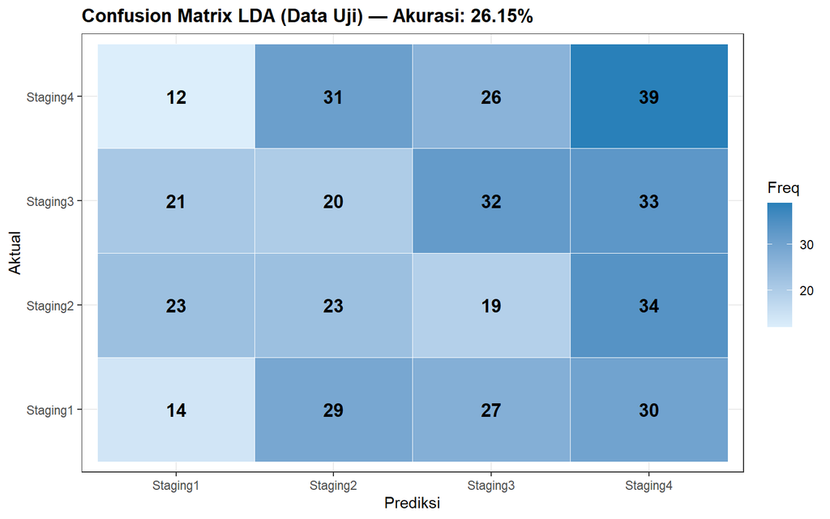

```r
cm_lda_df <- as.data.frame(cm_test_lda$table)
colnames(cm_lda_df) <- c("Prediksi", "Aktual", "Freq")

ggplot(cm_lda_df, aes(x = Prediksi, y = Aktual, fill = Freq)) +
  geom_tile(color = "white") +
  geom_text(aes(label = Freq), size = 4.5, fontface = "bold") +
  scale_fill_gradient(low = "#dceefb", high = "#2980b9") +
  labs(
    title = sprintf("Confusion Matrix LDA (Data Uji) — Akurasi: %.2f%%",
                    cm_test_lda$overall["Accuracy"] * 100),
    x = "Prediksi", y = "Aktual"
  ) +
  theme_bw(base_size = 11) +
  theme(plot.title = element_text(face = "bold"))
```

## 9.6 7.6 Confusion Matrix Heatmap — QDA (Data Uji)

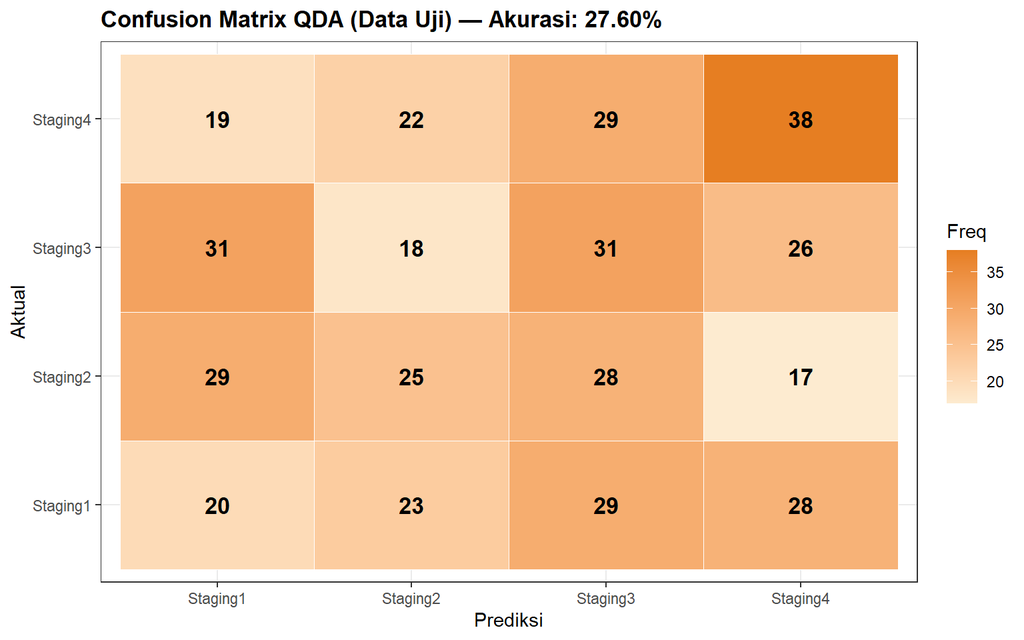

```r
cm_qda_df <- as.data.frame(cm_test_qda$table)
colnames(cm_qda_df) <- c("Prediksi", "Aktual", "Freq")

ggplot(cm_qda_df, aes(x = Prediksi, y = Aktual, fill = Freq)) +
  geom_tile(color = "white") +
  geom_text(aes(label = Freq), size = 4.5, fontface = "bold") +
  scale_fill_gradient(low = "#fdebd0", high = "#e67e22") +
  labs(
    title = sprintf("Confusion Matrix QDA (Data Uji) — Akurasi: %.2f%%",
                    cm_test_qda$overall["Accuracy"] * 100),
    x = "Prediksi", y = "Aktual"
  ) +
  theme_bw(base_size = 11) +
  theme(plot.title = element_text(face = "bold"))
```

## 9.7 7.7 Perbandingan Akurasi LDA vs QDA

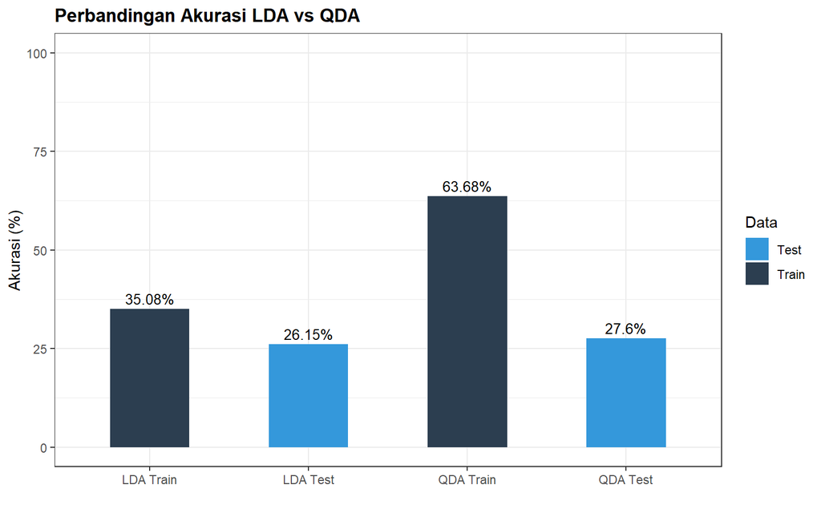

```r
acc_df <- data.frame(
  Model   = c("LDA Train", "LDA Test", "QDA Train", "QDA Test"),
  Akurasi = c(
    cm_train_lda$overall["Accuracy"] * 100,
    cm_test_lda$overall["Accuracy"]  * 100,
    cm_train_qda$overall["Accuracy"] * 100,
    cm_test_qda$overall["Accuracy"]  * 100
  ),
  Jenis = c("Train", "Test", "Train", "Test")
)
acc_df$Model <- factor(acc_df$Model, levels = acc_df$Model)

ggplot(acc_df, aes(x = Model, y = Akurasi, fill = Jenis)) +
  geom_bar(stat = "identity", width = 0.5) +
  geom_text(aes(label = paste0(round(Akurasi, 2), "%")),
            vjust = -0.4, size = 3.5) +
  scale_fill_manual(values = c("Train" = "#2c3e50", "Test" = "#3498db")) +
  ylim(0, 100) +
  labs(
    title = "Perbandingan Akurasi LDA vs QDA",
    x     = "",
    y     = "Akurasi (%)",
    fill  = "Data"
  ) +
  theme_bw(base_size = 11) +
  theme(plot.title = element_text(face = "bold"))
```

## 9.8 7.8 Distribusi Skor LD1 per Staging (Data Uji)

Plot densitas ini menunjukkan sejauh mana keempat kelas Staging terpisah pada sumbu LD1 setelah reduksi dimensi.

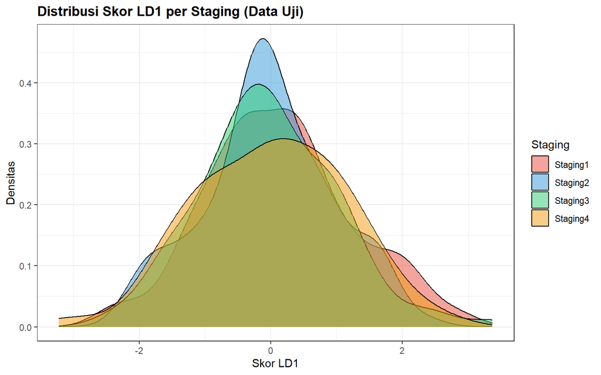

```r
lda_scores_test <- as.data.frame(pred_test_lda$x)
lda_scores_test$Staging <- data_test$Staging

ggplot(lda_scores_test, aes(x = LD1, fill = Staging)) +
  geom_density(alpha = 0.5) +
  scale_fill_manual(values = c("#e74c3c", "#3498db", "#2ecc71", "#f39c12")) +
  labs(
    title = "Distribusi Skor LD1 per Staging (Data Uji)",
    x     = "Skor LD1",
    y     = "Densitas",
    fill  = "Staging"
  ) +
  theme_bw(base_size = 11) +
  theme(plot.title = element_text(face = "bold"))
```

## 9.9 7.9 Distribusi Skor LD2 per Staging (Data Uji)

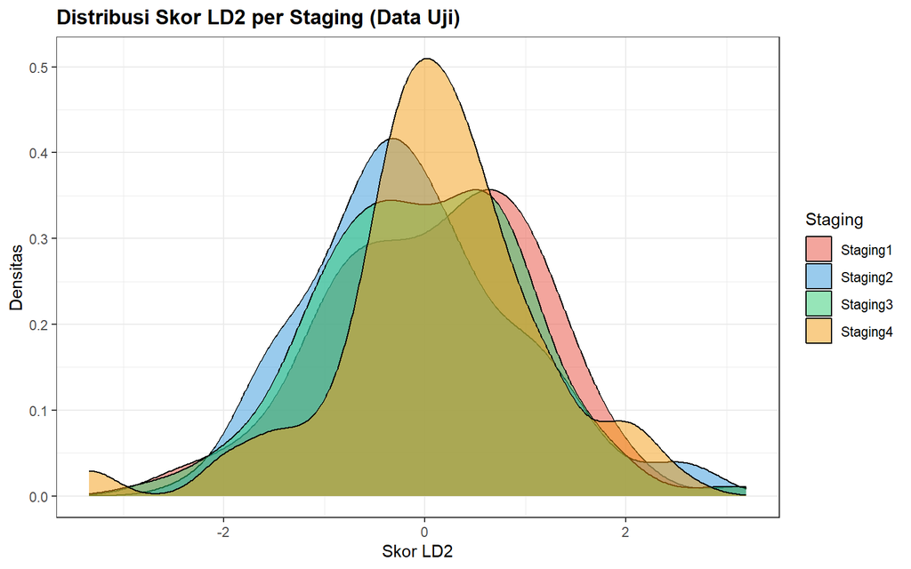

```r
ggplot(lda_scores_test, aes(x = LD2, fill = Staging)) +
  geom_density(alpha = 0.5) +
  scale_fill_manual(values = c("#e74c3c", "#3498db", "#2ecc71", "#f39c12")) +
  labs(
    title = "Distribusi Skor LD2 per Staging (Data Uji)",
    x     = "Skor LD2",
    y     = "Densitas",
    fill  = "Staging"
  ) +
  theme_bw(base_size = 11) +
  theme(plot.title = element_text(face = "bold"))
```

# 10 Partition Plot (Opsional)

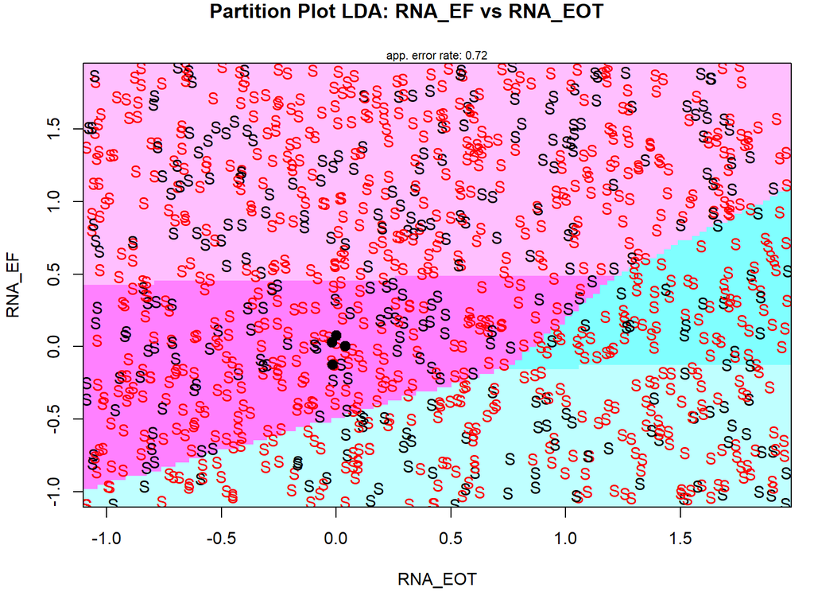

```r
partimat(
  Staging ~ RNA_EF + RNA_EOT,
  data   = df_scaled,
  method = "lda",
  main   = "Partition Plot LDA: RNA_EF vs RNA_EOT"
)
```

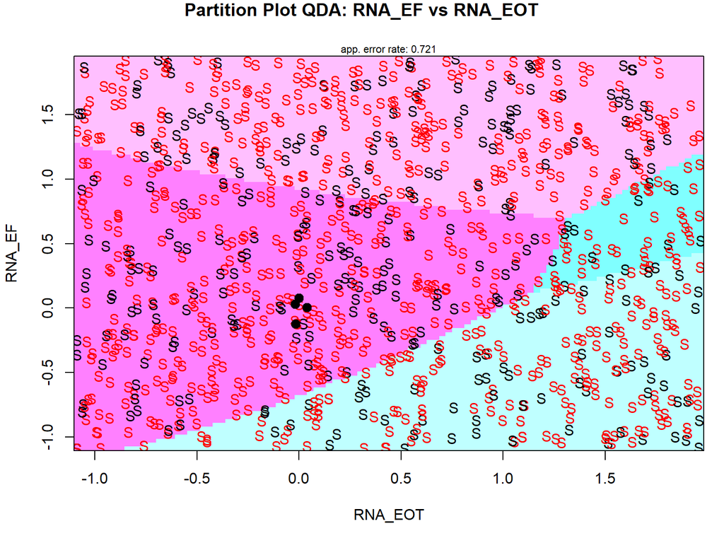

```r
partimat(
  Staging ~ RNA_EF + RNA_EOT,
  data   = df_scaled,
  method = "qda",
  main   = "Partition Plot QDA: RNA_EF vs RNA_EOT"
)
```

# 11 Kesimpulan

Analisis diskriminan pada dataset HCV Egyptian Patients menghasilkan temuan sebagai berikut:

**Pra-Pemrosesan:** Pengecekan duplikasi memastikan tidak ada observasi ganda dalam data. Outlier dideteksi menggunakan metode IQR dan ditangani dengan *winsorizing* (pem-*cap*-an pada batas $Q1 - 1.5 \times IQR$ dan $Q3 + 1.5 \times IQR$) untuk mempertahankan jumlah observasi sekaligus mengurangi pengaruh nilai ekstrem.

**Reduksi Dimensi via LDA:** LDA berhasil mereduksi dimensi fitur menjadi 3 fungsi diskriminan (LD1, LD2, LD3). LD1 menjelaskan porsi terbesar pemisahan antar kelas Staging, yang berarti sebagian besar informasi pembeda kelas dapat dirangkum hanya dalam satu dimensi baru.

**Perbandingan LDA vs QDA:**

- **LDA** mengasumsikan matriks kovarians yang sama antar kelas dan menghasilkan batas keputusan linear. Model ini lebih sederhana dan cenderung memiliki risiko overfitting yang lebih kecil.
- **QDA** mengasumsikan matriks kovarians yang berbeda tiap kelas sehingga batas keputusannya bersifat kuadratik dan lebih fleksibel, namun membutuhkan data yang lebih banyak.
- Nilai **Gap Overfit** (selisih akurasi train dan test) dapat digunakan untuk menilai kemampuan generalisasi masing-masing model.

[output not shown]